# Part 1

```python
import numpy as np
import matplotlib.pyplot as plt
import pandas as pd
import tensorflow as tf
import tensorflow.keras as k
import seaborn as sns
import cv2 as cv
```

```python
file_name2="D:\\Work_folders\\datasets\\Part-1 - Plant Seedling Classification Data-20210514T160322Z-001.zip"
#Please point to the file where the data located.
```

```python
##########################################################################
# Function that streams out the entire X_train and y_train kind of mechanism
##########################################################################
def figure_out_zip2(zip_file_path):
    out_list=[]
    labels=[]
    backup=[] # Not used here but can be used later on future for reference and cross checking
    from zipfile import ZipFile
    import numpy as np
    from PIL import Image
    from io import BytesIO
    import cv2 as cv
    ####################################################
    ####################################################
    file_name=zip_file_path
    myfile=ZipFile(file_name,'r')
    images=np.array([])
    #image_name_list=myfile.infolist().filename
    for each in myfile.infolist():
        try:
            file_temp=each.filename.split("/")
            #print(each.filename)
            img=Image.open(BytesIO(myfile.read(each.filename)))
            backup.append(file_temp[-1])
            labels.append(file_temp[-2])
            img=np.array(img)
            #plt.imshow(img)
            #print(img.shape)
            #images=np.append(images,img)
            out_list.append(img)
        except:
            print("Invalid file type",file_temp[-1])
    #print(images.shape)
    myfile.close()
    return out_list,np.array(labels) #,backup - Uncomment this to collect the file names for cross reference lateron.
##########################################################################
# End of Function
##########################################################################
```

```python
photos2,labels2=figure_out_zip2(file_name2)
```

```
Invalid file type .DS_Store
```

```python
np.unique(labels2)
```

```
array(['Black-grass', 'Charlock', 'Cleavers', 'Common Chickweed',
       'Common wheat', 'Fat Hen', 'Loose Silky-bent', 'Maize',
       'Scentless Mayweed', 'Seedling - Prediction', 'Shepherds Purse',
       'Small-flowered Cranesbill', 'Sugar beet'], dtype='<U25')
```

```python
photos2[1].shape
```

```
(63, 63, 3)
```

```python
length_tuples=[]
for each in photos2:
    length_tuples.append(each.shape)
```

```python
pd.DataFrame(length_tuples,columns={"height","width","colors"}).describe()
```

|  | colors | height | width |
| --- | --- | --- | --- |
| count | 4768.000000 | 4768.000000 | 4768.000000 |
| mean | 370.087248 | 370.820260 | 3.005034 |
| std | 318.324079 | 322.938251 | 0.070776 |
| min | 49.000000 | 49.000000 | 3.000000 |
| 25% | 140.000000 | 140.000000 | 3.000000 |
| 50% | 264.500000 | 264.500000 | 3.000000 |
| 75% | 506.000000 | 507.000000 | 3.000000 |
| max | 3457.000000 | 3991.000000 | 4.000000 |

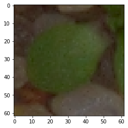

```python
plt.imshow(photos2[21])
```

```python
######################################################################
# used to standardize images
######################################################################
def standardize_images(photos2):
    from skimage.transform import resize
    photos_resized=[]
    for each in photos2:
        photos_resized.append(resize(each,(32,32)))
    return photos_resized
######################################################################
# end of function
######################################################################
photos_resized=standardize_images(photos2)
```

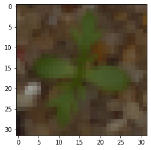

```python
plt.imshow(photos_resized[14])
```

```python
length_tuples=[]
for each in photos_resized:
    length_tuples.append(each.shape)

pd.DataFrame(length_tuples).describe()
```

|  | 0 | 1 | 2 |
| --- | --- | --- | --- |
| count | 4768.0 | 4768.0 | 4768.000000 |
| mean | 32.0 | 32.0 | 3.005034 |
| std | 0.0 | 0.0 | 0.070776 |
| min | 32.0 | 32.0 | 3.000000 |
| 25% | 32.0 | 32.0 | 3.000000 |
| 50% | 32.0 | 32.0 | 3.000000 |
| 75% | 32.0 | 32.0 | 3.000000 |
| max | 32.0 | 32.0 | 4.000000 |

Note here there is a slight problem i.e. a fourth dimensions is involved, which in this present context is completely useless and doesn't carry any information regarding the given situation.

```python
for i in range(len(photos_resized)):
    if photos_resized[i].shape[2]!=3:
        photos_resized[i]=photos_resized[i][:,:,:-1]
        print("The Number of image :\n",i)
        print(photos_resized[i][:,:,:-1])
```

[output not shown]

[output cut: 1169 more lines]

[output not shown]

```python
#This is just a check to see the data and check if everything is going good.
print(photos_resized[14])
print(photos_resized[14].reshape(-1))
```

```
[[[0.3321605  0.25490196 0.16745462]
  [0.31017157 0.24819719 0.16443493]
  [0.28204657 0.22536765 0.14358437]
  ...
  [0.38484701 0.31875    0.25281863]
  [0.38317536 0.3151348  0.2537636 ]
  [0.36648284 0.29981618 0.24099265]]

 [[0.38180147 0.30199621 0.20573395]
  [0.32800245 0.25118049 0.15706284]
  [0.32830882 0.25232843 0.15036765]
  ...
  [0.35551471 0.28284984 0.21433824]
  [0.34137657 0.27722216 0.20663392]
  [0.34519474 0.26927562 0.19372415]]

 [[0.41401367 0.35183824 0.26211416]
  [0.3314951  0.24773284 0.1713781 ]
  [0.35713944 0.28835784 0.20208333]
  ...
  [0.26458333 0.18930856 0.13593654]
  [0.26237075 0.18639036 0.12438725]
  [0.33829657 0.23623813 0.12193627]]

 ...

 [[0.14865196 0.11335784 0.09824123]
  [0.24234069 0.20275065 0.15901405]
  [0.31580882 0.26482843 0.20180664]
  ...
  [0.32864679 0.27843137 0.22429439]
  [0.35790441 0.31439951 0.25698529]
  [0.35136623 0.31084559 0.23915441]]

 [[0.13182732 0.08553922 0.07906997]
  [0.1995098  0.14551068 0.12469363]
  [0.29368873 0.23878676 0.17995653]
  ...
  [0.29515261 0.24313725 0.18823529]
  [0.30729167 0.24846814 0.19215686]
  [0.34332108 0.28918984 0.21984337]]

 [[0.12512255 0.07139342 0.0723652 ]
  [0.18539082 0.13186275 0.11262255]
  [0.27418524 0.21488971 0.16286765]
  ...
  [0.31194853 0.2620098  0.20710784]
  [0.32367781 0.25955882 0.20073529]
  [0.34509804 0.28627451 0.21960784]]]
[0.3321605  0.25490196 0.16745462 ... 0.34509804 0.28627451 0.21960784]
```

```python
photos_resized[1].shape[2]
```

```
3
```

# Supervised Machine Learning Approach

We are going to use three supervise machine learning algorithms here. 1. KNN 2. Logistic Regression 3. SVM

```python
x=np.array(photos_resized)
y=np.array(labels2)
x=x.reshape(x.shape[0],-1)
```

```python
print("The Shapes of the new data are : ",x.shape,y.shape) # Note here that each picture of the standard size is now reduced to
```

```
The Shapes of the new data are :  (4768, 3072) (4768,)
```

```python
######################################################################
import seaborn as sns
from sklearn import metrics
from sklearn.linear_model import LogisticRegression
from sklearn.neighbors import KNeighborsClassifier
from sklearn.svm import SVC
from sklearn.model_selection import train_test_split
from sklearn.metrics import accuracy_score
from sklearn.metrics import recall_score
#from sklearn.metrics import classification_report
from sklearn.metrics import roc_auc_score as area_under_curve
######################################################################

support_vector = SVC(C=10000,probability=True)
LR_model = LogisticRegression(solver="liblinear")
KNN = KNeighborsClassifier(n_neighbors= 10 , weights = 'distance')

###########################################################################
x_train,x_test,y_train,y_test=train_test_split(x,y,test_size=0.2,random_state=1)
```

```python
x_train.shape #Checking for reference.
```

```
(3814, 3072)
```

```
Logistic Regression Model Score for Train Set :  0.8744100681699004

Logistic Regression Model Score for Test Set :  0.4727463312368973

Logistic Regression Mapping
```

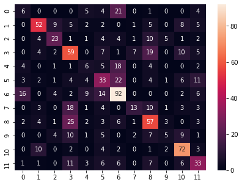

```python
######################################################################
# Logistic Regression
######################################################################
LR_model.fit(x_train,y_train)
predict_LR = LR_model.predict(x_test)
####################################################
Accuracy_LR = accuracy_score(y_test, predict_LR)
Recall_LR = recall_score(y_test, predict_LR,average=None)
confusion_LR=metrics.confusion_matrix(y_test, predict_LR)
LR_Testscore=LR_model.score(x_test,y_test)
LR_Trainscore=LR_model.score(x_train,y_train)
#auc_LR=area_under_curve(y_test,predict_LR)
#####################################################
print("\nLogistic Regression Model Score for Train Set : ", LR_Trainscore)
print("\nLogistic Regression Model Score for Test Set : ", LR_Testscore)
#####################################################
df_confusion_LR = pd.DataFrame(confusion_LR)
print("\nLogistic Regression Mapping")
plt.figure(figsize = (7,5))
sns.heatmap(df_confusion_LR, annot=True)
######################################################################
#
######################################################################
```

**Note** : Something is seriously off with this model, we have to see that regression doesn't seem to fit it at all, strongly indicating that there needs to be one crucial element i.e. back propagation viz. the back bone of the Neural Network and we need to multiple layers, since here it serves as only one single perceptron, so it is more likely to make mistakes.

```python
print("The Original Image is shown below, of the test set :")
plt.imshow(x_test[1].reshape(32,32,3))
print("\n\nThe Predicated Label is :",predict_LR[1],"\nOriginal Label is :",y_test[1])
```

[output not shown]

```
The Original Image is shown below, of the test set :


The Predicated Label is : Common wheat
Original Label is : Fat Hen
```

```
KNN Model Train Score : 1.0

KNN Model Test Score : 0.24737945492662475

Confusion Matrix Mapping
```

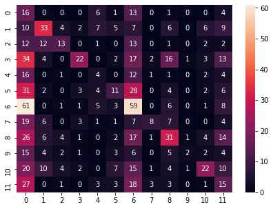

```python
######################################################################
# K Nearest Neighbors
######################################################################
KNN.fit(x_train, y_train)
predict_KNN = KNN.predict(x_test)
####################################################
confusion_KNN=metrics.confusion_matrix(y_test, predict_KNN)
Accuracy_KNN = accuracy_score(y_test, predict_KNN)
Recall_KNN = recall_score(y_test, predict_KNN,average=None)
KNN_Testscore=KNN.score(x_test,y_test)
KNN_Trainscore=KNN.score(x_train,y_train)
####################################################
print("\nKNN Model Train Score :",KNN_Trainscore)
print("\nKNN Model Test Score :",KNN_Testscore)
####################################################
df_confusion_KNN = pd.DataFrame(confusion_KNN)
print("\nConfusion Matrix Mapping")
plt.figure(figsize = (7,5))
sns.heatmap(df_confusion_KNN, annot=True)
######################################################################
#
######################################################################
```

```python
print("The Original Image is shown below, of the test set :")
plt.imshow(x_test[1].reshape(32,32,3))
print("\n\nThe Predicated Label is :",predict_KNN[1],"\nOriginal Label is :",y_test[1])
```

[output not shown]

```
The Original Image is shown below, of the test set :


The Predicated Label is : Loose Silky-bent
Original Label is : Fat Hen
```

**Observations** :

If you observe the heatmap it is too much biased around one single point, which is a strong indication that most probably it is stuck in either local maxima/minima or that it has an exploding gradient problem. The former I think is true and hence, is unable to pickup any differences.

```
Support Vector Machine Model Test Score : 0.5712788259958071

Support Vector Machine Model Train Score : 0.9997378080755113

Confusion Matrix Mapping
```

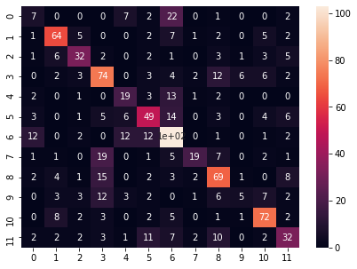

```python
######################################################################
# Support Vector Machine
######################################################################
support_vector.fit(x_train, y_train)
predict_SVM = support_vector.predict(x_test)
####################################################
confusion_SVM=metrics.confusion_matrix(y_test, predict_SVM)
Accuracy_SVM = accuracy_score(y_test, predict_SVM)
Recall_SVM = recall_score(y_test, predict_SVM,average=None)
support_vector_Testscore=support_vector.score(x_test, y_test)
support_vector_Trainscore=support_vector.score(x_train, y_train)
####################################################
print("\nSupport Vector Machine Model Test Score :",support_vector_Testscore)
print("\nSupport Vector Machine Model Train Score :",support_vector_Trainscore)
####################################################
df_confusion_SVM = pd.DataFrame(confusion_SVM)
print("\nConfusion Matrix Mapping")
plt.figure(figsize = (7,5))
sns.heatmap(df_confusion_SVM, annot=True)
######################################################################
#
######################################################################
```

```python
print("The Original Image is shown below, of the test set :")
plt.imshow(x_test[1].reshape(32,32,3))
print("\n\nThe Predicated Label is :",predict_SVM[1],"\nOriginal Label is :",y_test[1])
```

[output not shown]

```
The Original Image is shown below, of the test set :


The Predicated Label is : Loose Silky-bent
Original Label is : Fat Hen
```

```python
len(np.unique(y)) # To account for the number of output neurons for setting up neural network.
```

```
13
```

# Neural Networks

```python
from tensorflow.keras.utils import to_categorical
from sklearn.preprocessing import OneHotEncoder
from tensorflow.keras.layers import Conv2D
import tensorflow as tf
import tensorflow
from tensorflow.keras.models import Sequential
from tensorflow.keras.layers import Conv2D, MaxPooling2D, Flatten, Dense, Dropout,BatchNormalization
from tensorflow.keras.layers import Reshape
from tensorflow.keras.utils import to_categorical
```

```python
from sklearn.model_selection import train_test_split
x_train,x_test,y_train,y_test=train_test_split(x,y,test_size=0.2,random_state=1)
```

```python
#Building the dicionary for future.
dictionary={}
j=0
for each in np.unique(y):
    dictionary.update({each:j})
    j+=1
```

```python
def encode_to_strings(y_given,dictionary_given):
    y_train=y_given
    for i in range(len(y_train)):
        for each in dictionary:
            if y_train[i]==each:
                y_train[i]=dictionary[each]
    return y_train
```

```python
y_train=encode_to_strings(y_train,dictionary)
y_test=encode_to_strings(y_test,dictionary)
```

```python
#x_train = x_train.reshape(x_train.shape[0], 64, 64, 4)[:,:,:,:-1]
#x_test = x_test.reshape(x_test.shape[0], 64, 64, 4)[:,:,:,:-1]
y_train = to_categorical(y_train)
y_test = to_categorical(y_test)
#y_train=OneHotEncoder().fit_transform(y_train.reshape(-1, 1))
#y_test=OneHotEncoder().fit_transform(y_test.reshape(-1, 1))
```

```python
x_train=x_train.astype("float32").reshape(x_train.shape[0],32,32,3)
x_test=x_test.astype("float32").reshape(x_test.shape[0],32,32,3)
```

```python
print(y_train[12])
```

```
[0. 0. 0. 1. 0. 0. 0. 0. 0. 0. 0. 0. 0.]
```

```python
x_train.shape
```

```
(3814, 32, 32, 3)
```

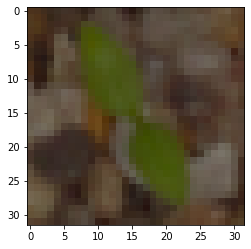

```python
plt.imshow(x_train[12])
```

# Fully Connected Neural Network

```python
from tensorflow.keras import regularizers, optimizers
import time
###################################################################
#Categorical Neural Network
###################################################################
model_cat_1=k.Sequential()
model_cat_1.add(Flatten(input_shape=(32,32,3)))

#model_cat_1.add(BatchNormalization())
model_cat_1.add(Dense(60,activation="sigmoid",kernel_initializer='random_normal',bias_initializer='zeros',kernel_regularizer="l2",bias_regularizer="l2"))
model_cat_1.add(Dropout(0.2, input_shape=(60,)))
#model_cat_1.add(Dense(30,activation="relu",kernel_initializer='random_normal',bias_initializer='zeros',kernel_regularizer="l2",bias_regularizer="l2"))
#model_cat_1.add(Dropout(0.2, input_shape=(30,)))
#model_cat_1.add(Dense(60,activation="sigmoid",kernel_initializer='random_normal',bias_initializer='zeros',kernel_regularizer="l2",bias_regularizer="l2"))
#model_cat_1.add(Dropout(0.4, input_shape=(60,)))
#model_cat_1.add(Dense(60,activation="relu",kernel_initializer="random_normal",bias_initializer='zeros',kernel_regularizer="l2",bias_regularizer="l2"))
#model_cat_1.add(Dropout(0.2, input_shape=(60,)))
#model_cat_1.add(Dense(60,activation="sigmoid",kernel_initializer='random_normal',bias_initializer='zeros',kernel_regularizer="l2",bias_regularizer="l2"))
#model_cat_1.add(Dropout(0.4, input_shape=(60,)))
#model_cat_1.add(Dense(30,activation="sigmoid",kernel_initializer='random_normal',bias_initializer='zeros',kernel_regularizer="l2",bias_regularizer="l2"))
#model_cat_1.add(Dropout(0.2, input_shape=(30,)))
#model_cat_1.add(Dense(30,activation="sigmoid",kernel_initializer='random_normal',bias_initializer='zeros',kernel_regularizer="l2",bias_regularizer="l2"))
#model_cat_1.add(Dropout(0.2, input_shape=(30,)))
model_cat_1.add(Dense(25,activation="sigmoid",kernel_initializer="random_normal",bias_initializer='zeros',kernel_regularizer="l2",bias_regularizer="l2"))
model_cat_1.add(Dense(13,activation="softmax"))
sgd = optimizers.SGD(lr = 0.01,momentum=0.3)
model_cat_1.compile(optimizer = sgd, loss = 'mse', metrics =k.metrics.CategoricalAccuracy())

t=time.time()
###################################################################
#
###################################################################
history_cat_1=model_cat_1.fit(x_train,y_train,batch_size=15, validation_split=0.2, epochs = 100, verbose = 1)
print("Total Time Taken is : ",t-time.time())
```

```
Total Time Taken is :  -50.96673274040222
```

```
dict_keys(['loss', 'categorical_accuracy', 'val_loss', 'val_categorical_accuracy'])
```

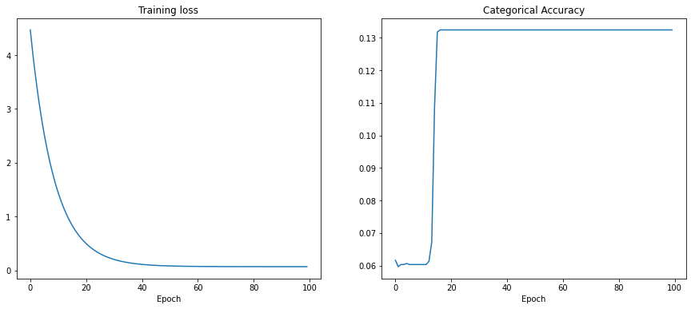

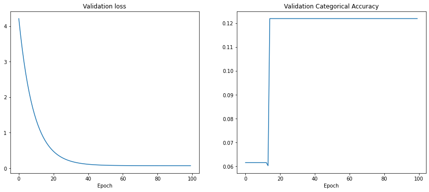

```python
history=history_cat_1.history
print(history.keys())
fig=plt.figure(figsize=(15,6))
ax=fig.add_subplot(1,2,1)
ax.plot(history["loss"])
ax.set_title("Training loss")
ax.set_xlabel("Epoch")
ax.tick_params(axis="both",which="major")
ax=fig.add_subplot(1,2,2)
ax.plot(history["categorical_accuracy"])
ax.set_title("Categorical Accuracy")
ax.set_xlabel("Epoch")
ax.tick_params(axis="both",which="major")
plt.show()
#
fig=plt.figure(figsize=(15,6))
ax=fig.add_subplot(1,2,1)
ax.plot(history["val_loss"])
ax.set_title("Validation loss")
ax.set_xlabel("Epoch")
ax.tick_params(axis="both",which="major")
ax=fig.add_subplot(1,2,2)
ax.plot(history["val_categorical_accuracy"])
ax.set_title("Validation Categorical Accuracy")
ax.set_xlabel("Epoch")
ax.tick_params(axis="both",which="major")
plt.show()
```

```python
###################################################################
# Slightly modified version of the above
###################################################################
model_cat_2=k.Sequential()
model_cat_2.add(Flatten(input_shape=(32,32,3)))

#model_cat_2.add(BatchNormalization())
model_cat_2.add(Dense(60,activation="sigmoid",kernel_initializer='random_normal',bias_initializer='zeros',kernel_regularizer="l2",bias_regularizer="l2"))
model_cat_2.add(Dropout(0.2, input_shape=(60,)))
#model_cat_2.add(Dense(30,activation="relu",kernel_initializer='random_normal',bias_initializer='zeros',kernel_regularizer="l2",bias_regularizer="l2"))
#model_cat_2.add(Dropout(0.2, input_shape=(30,)))
#model_cat_2.add(Dense(60,activation="sigmoid",kernel_initializer='random_normal',bias_initializer='zeros',kernel_regularizer="l2",bias_regularizer="l2"))
#model_cat_2.add(Dropout(0.4, input_shape=(60,)))
#model_cat_2.add(Dense(60,activation="relu",kernel_initializer="random_normal",bias_initializer='zeros',kernel_regularizer="l2",bias_regularizer="l2"))
#model_cat_2.add(Dropout(0.2, input_shape=(60,)))
#model_cat_2.add(Dense(60,activation="sigmoid",kernel_initializer='random_normal',bias_initializer='zeros',kernel_regularizer="l2",bias_regularizer="l2"))
#model_cat_2.add(Dropout(0.4, input_shape=(60,)))
#model_cat_2.add(Dense(30,activation="sigmoid",kernel_initializer='random_normal',bias_initializer='zeros',kernel_regularizer="l2",bias_regularizer="l2"))
#model_cat_2.add(Dropout(0.2, input_shape=(30,)))
#model_cat_2.add(Dense(30,activation="sigmoid",kernel_initializer='random_normal',bias_initializer='zeros',kernel_regularizer="l2",bias_regularizer="l2"))
#model_cat_2.add(Dropout(0.2, input_shape=(30,)))
model_cat_2.add(Dense(25,activation="sigmoid",kernel_initializer="random_normal",bias_initializer='zeros',kernel_regularizer="l2",bias_regularizer="l2"))
model_cat_2.add(Dense(13,activation="softmax"))
adam = optimizers.Adam(lr = 0.01)
model_cat_2.compile(optimizer = adam, loss = 'mse', metrics =k.metrics.CategoricalAccuracy())

t=time.time()
###################################################################
#
###################################################################
history_cat_2=model_cat_2.fit(x_train,y_train,batch_size=15, validation_split=0.2, epochs = 100, verbose = 1)
print("Total Time Taken is : ",t-time.time())
```

```
Total Time Taken is :  -50.09408164024353
```

```
dict_keys(['loss', 'categorical_accuracy', 'val_loss', 'val_categorical_accuracy'])
```

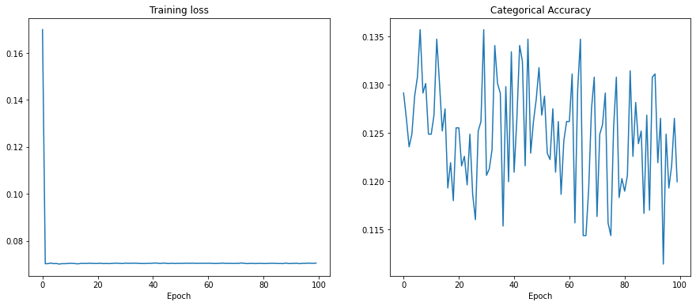

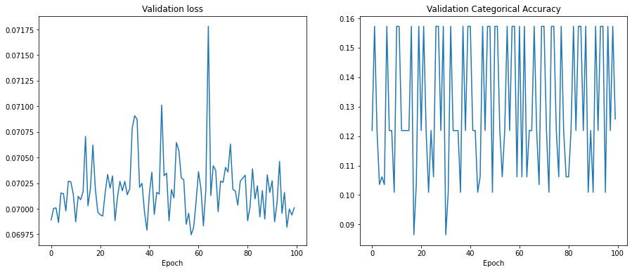

```python
history=history_cat_2.history
print(history.keys())
fig=plt.figure(figsize=(15,6))
ax=fig.add_subplot(1,2,1)
ax.plot(history["loss"])
ax.set_title("Training loss")
ax.set_xlabel("Epoch")
ax.tick_params(axis="both",which="major")
ax=fig.add_subplot(1,2,2)
ax.plot(history["categorical_accuracy"])
ax.set_title("Categorical Accuracy")
ax.set_xlabel("Epoch")
ax.tick_params(axis="both",which="major")
plt.show()
#
fig=plt.figure(figsize=(15,6))
ax=fig.add_subplot(1,2,1)
ax.plot(history["val_loss"])
ax.set_title("Validation loss")
ax.set_xlabel("Epoch")
ax.tick_params(axis="both",which="major")
ax=fig.add_subplot(1,2,2)
ax.plot(history["val_categorical_accuracy"])
ax.set_title("Validation Categorical Accuracy")
ax.set_xlabel("Epoch")
ax.tick_params(axis="both",which="major")
plt.show()
```

# Convolutional Neural Network

```python
# Initialize the model
model = Sequential()

# Add a Convolutional Layer with 32 filters of size 3X3 and activation function as 'relu'
model.add(Conv2D(filters=32, kernel_size=3, activation="relu", input_shape=(32,32,3)))

# Add a Convolutional Layer with 64 filters of size 3X3 and activation function as 'relu'
model.add(Conv2D(filters=64, kernel_size=3, activation="relu"))

# Add a MaxPooling Layer of size 2X2
model.add(MaxPooling2D(pool_size=(2, 2)))

# Apply Dropout with 0.2 probability
model.add(Dropout(rate=0.2))

# Flatten the layer
model.add(Flatten())

# Add Fully Connected Layer with 128 units and activation function as 'relu'
model.add(Dense(128, activation="relu",kernel_initializer='random_uniform',kernel_regularizer="l2",bias_regularizer="l2"))

#Add Fully Connected Layer with 10 units and activation function as 'softmax'
model.add(Dense(13, activation="softmax",kernel_initializer='random_uniform',kernel_regularizer="l2",bias_regularizer="l2"))

# Compile the model
model.compile(loss="categorical_crossentropy", metrics=["accuracy"], optimizer="adam")

# Use earlystopping
#callback = tensorflow.keras.callbacks.EarlyStopping(monitor='val_acc', patience=2, min_delta=0.1)

# Fit the model
model.fit(x=x_train, y=y_train, batch_size=12, epochs=30,validation_data=(x_test, y_test))#, callbacks=[callback])
```

```
<tensorflow.python.keras.callbacks.History at 0x233dce08190>
```

```python
model.evaluate(x_test, y_test)
```

```
[1.1801501512527466, 0.7306079864501953]
```

# Picking the model

```python
model.save('part1-Botanical.sav')
model = tf.keras.models.load_model('part1-Botanical.sav')
```

```
INFO:tensorflow:Assets written to: part1-Botanical.sav\assets
```

With so good facility in Tensorflow to save models, it is not a necessity to use the serialized models of pickle to save models as its going to cause headache, like it did in my previous project. So, using Tf model save methods here. But pickle methods are given here anyhow.

```python
#import pickle
#with open("part1-Botanical.save", 'w') as file:
    #pickle.dump(model,file)
###########################################
#with open("part1-Botanical.save", 'r') as file:
    #model2 = pickle.load(file)
```

# Predicting the class of given picture

```python
img_predict=cv.imread("predict.png")
```

```
The imported picture is given below :
```

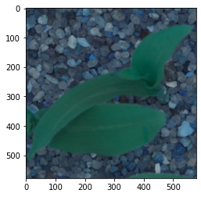

```python
print("The imported picture is given below :")
plt.imshow(img_predict)
```

```python
print(img_predict.shape)
```

```
(578, 578, 3)
```

```python
img_predict=standardize_images([img_predict])[0]
```

[output not shown]

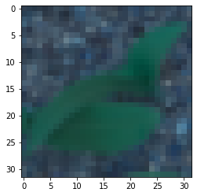

```python
print(img_predict.shape)
plt.imshow(img_predict)
```

```python
model.summary()
```

```
Model: "sequential_2"
_________________________________________________________________
Layer (type)                 Output Shape              Param #
=================================================================
conv2d (Conv2D)              (None, 30, 30, 32)        896
_________________________________________________________________
conv2d_1 (Conv2D)            (None, 28, 28, 64)        18496
_________________________________________________________________
max_pooling2d (MaxPooling2D) (None, 14, 14, 64)        0
_________________________________________________________________
dropout_2 (Dropout)          (None, 14, 14, 64)        0
_________________________________________________________________
flatten_2 (Flatten)          (None, 12544)             0
_________________________________________________________________
dense_6 (Dense)              (None, 128)               1605760
_________________________________________________________________
dense_7 (Dense)              (None, 13)                1677
=================================================================
Total params: 1,626,829
Trainable params: 1,626,829
Non-trainable params: 0
_________________________________________________________________
```

```python
prediction = model.predict(img_predict.reshape(1,32,32,3))[0] #Here we got probabilities for predictions.
```

```
The label of the figure is :
Cleavers
```

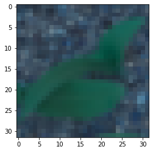

```python
for i in range(13):
    if prediction.max()==prediction[i]:
        print("The label of the figure is :")
        plt.imshow(img_predict)
        print(np.unique(labels2)[i])
        break
```

# Part 2

**Why does CNN out perform Neural Networks and other supervised Learning Mechanism ?** We can clearly see here that CNN is tremendously powerful than other image processing algorithms. Supervisied algorithms is pretty linear and straight forward. They don't provide scope for back propagation or non-liearity. They don't even have multiple slopes possible for perceptrons in them. Hence, they are most likely to fall into the trap of falling inside the localized minimum. They forget about global minimum and traditional opitimization algorithms don't work, especially when maxima/minima are placed too far apart. So, when we are dealing with, say a monochrome picture, then they are likely to get stuck in a white patch somewhere outside our area of interest and most likely to loose all the information. They are heavily perceptible to noise.

Hence it becomes very important, for any learning algorithm, to not get stuck at one single place i.e. they need some kind of back propagation mechanism that keeps informing the perceptron (a simple linear regressor can be thought as a single perceptron) with a feedback that it still hasn't achieved the minimum. Hence, we need a feedback mechanism. But, if we can expose this propagation forward and backward in such a way that they function as units that restrict themselves to specific areas/range of inputs for each feature i.e. make it layered so that each layer handles different portions or areas slopes/valleys and somehow all of them combine together.

When we have Neural Networks that is layered and also broken down into different combinations for input features to taken in, though seeming like random, it establishes a mechanism for forwards and backward propagation and the slope (now called weights) are established and studied with dynamic learning happening.

But, when it comes to image data, most of the time the data is non-linear. But the most important thing about Neural Network(or for that matter any kind of machine learning) is that it is prone to non-convergence and overfitting. So, it so happens that there are a number of things, especially noise, that dictate a lot of things and make the model suspeptible to noise and tend to overfit and poorly perform. Hence, as was the case with audio fitting and all, we need some standardized mechanisms/comparison with respect to which we have to compare our data/images, and try to project onto that. It might even be understood as a kernel. This fitting into a kernel standardizes any tiny differences across a given interval/domain. This smoothing is just one such thing that is going to reduce noise. Another approach is to increase or magnify the differences between the components/colors thereby making the objects separate from each other. So, a sharpened edge detector followed by a blurr filter (filtering is a kind of a kernel method, in other words convolution) is going to create a lot of clear cut features from our image and reduce background noise, and make learning simpler and easier.

If we put multiple such filters on top of each other and create a series of outputs (either from one to another or in parallel), we will create an extremely feature rich information that is approrpriately representing the information without noise. The ideas go into the concepts of Signal Analysis, which is out of scope here.

But we can turn such convolution into simply a layer and we can continue our process, just like how we flatten or normalize the given input in the form a layer. As long as its a hidden layer, it doesn't interfere. This is the idea of Convolution applied to Images.

**To the Evaluator** I thought this is the better place to discuss and demonstrate how various filters work. So, instead of dealing with them in the part 4 of the project, it is dealt with here. The OpenCV library has been used to demonstrate pictures via filters here.

[figure not shown]

```python
import cv2
image=cv2.imread("C:\\Users\\Sheshank_Joshi\\Dropbox\\code\\jupyter-AIML\\Projects\\Project 8 - Computer Vision\\17flowers\\jpg\\5\\image_0403.jpg")
plt.imshow(image)
```

```python
image.shape
```

```
(500, 524, 3)
```

**Averaging Filter**

```python
###################################################################
# Function that shows various filters in comparison with original with applied filters
###################################################################

def display_filters_conv2D(img,kernel):
    import cv2
    filtered_image = cv2.filter2D(img,-1,kernel)
    plt.subplot(121),plt.imshow(img),plt.title('Original')
    plt.xticks([]), plt.yticks([])
    plt.subplot(122),plt.imshow(filtered_image),plt.title("Image with Filter")
    plt.xticks([]), plt.yticks([])
    plt.show()
###################################################################
# End of Function
###################################################################
```

**Some Experiments with Custom Kernels**

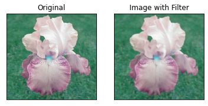

```python
kernel1 = np.ones((5,5),np.float32)/25 #Averaging Kernel over 5 pixels
display_filters_conv2D(image,kernel1)
```

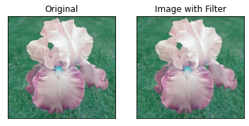

```python
kernel2 = np.ones((3,3),np.float32)/9 #Averaging Kernel over 3 pixels
display_filters_conv2D(image,kernel2)
```

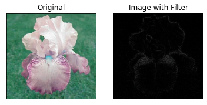

```python
kernel3=np.array([[0,-1,0],[-1,4,-1],[0,-1,0]])
display_filters_conv2D(image,kernel3)
```

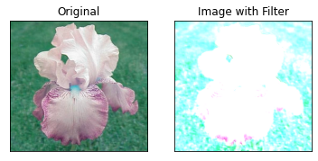

```python
kernel4=np.array([[1,0,0],[0,1,0],[0,0,1]])
display_filters_conv2D(image,kernel4)
```

```python
kernel4=np.array([[1/9,0,0],[0,1/9,0],[0,0,1/9]])
display_filters_conv2D(image,kernel4)
```

[output not shown]

```python
kernel5=np.transpose(kernel4)
display_filters_conv2D(image,kernel5)
```

[output not shown]

```python
kernel6=np.transpose(kernel5)
display_filters_conv2D(image,kernel6)
```

[output not shown]

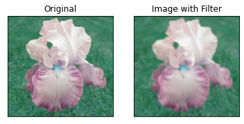

```python
kernel7 = np.ones((10,10),np.float32)/100 #Averaging Kernel over 5 pixels. it becomes more blurry.
display_filters_conv2D(image,kernel7)
```

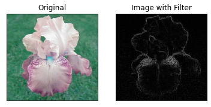

```python
kernel8=np.array([[-1,-1,-1],[-1,8,-1],[-1,-1,-1]]) #Contour Detection filter (strong)
display_filters_conv2D(image,kernel8)
```

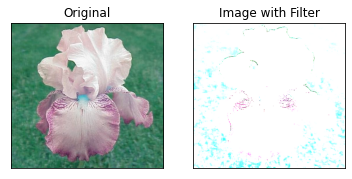

```python
kernel9=np.array([[-1,-1,-1],[-1,13,-1],[-1,-1,-1]]) # this is an excellent filter that makes the background disappear.
display_filters_conv2D(image,kernel9)
```

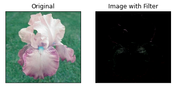

```python
kernel11=np.array([[1/4,1,1/4],[1,-2,1],[0,-1,-1]])
display_filters_conv2D(image,kernel11)
```